# EDA Project

## 1. Missing/Inconsistent Value

```python
#Crime returns 2011 where Violent Crime is not reported. We keep this value becuase Property Crime is reported.
#We also keep 2020 as an empty year as a placeholder for calculation purposes and creation of future variables. It will not be used in analysis.
crime[crime.isnull().any(axis=1)]
```

|  | Year | Population | Violent Crime | Property Crime |
| --- | --- | --- | --- | --- |
| 0 | 2020 | NaN | NaN | NaN |
| 9 | 2011 | 2703713.0 | NaN | 118239.0 |

```python
#This returns no values, because there are no null values in the 'budget' dataset
budget[budget.isnull().any(axis=1)]
```

|  | Year | Corporate Fund | Police Budget |
| --- | --- | --- | --- |

## 2. Duplicates

Because the dataset was handcurated and each row was taken from a different table/report, there should be no duplicate values. We will analyze for outliers in part 4.

```python
crime['Year'].duplicated().any() #returns False: there are no duplicate years in the 'crime' dataset
```

```
False
```

```python
budget['Year'].duplicated().any() #returns False: there are no duplicate years in the 'budget' dataset
```

```
False
```

## 3. Column Selection

Because the dataset was handcurated and each row was taken from a different table/report, all columns will be utilized in either the analysis or the creation of additional columns (referenced in the data dictionary).

## 4. Outliers

All numeric variables (aside from year) are analyzed below. Of the 5 columns and 2 datasets, there is only 1 outlier.

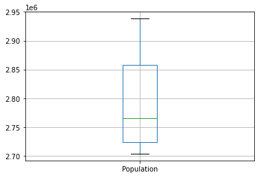

```python
crime.boxplot(column = 'Population') #no outliers
```

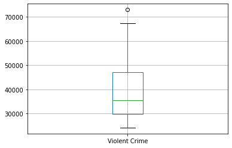

```python
crime.boxplot(column = 'Violent Crime') #1 outlier,
```

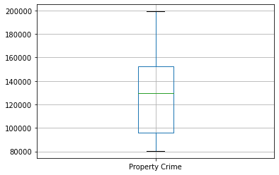

```python
crime.boxplot(column = 'Property Crime') # no outliers
```

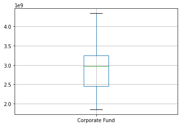

```python
budget.boxplot(column = 'Corporate Fund') # no outliers
```

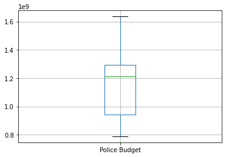

```python
budget.boxplot(column = 'Police Budget') # no outliers
```

```python
#Violent Crime is the only column with in outlier
crime[crime['Violent Crime'] > 70000]
```

|  | Year | Population | Violent Crime | Property Crime |
| --- | --- | --- | --- | --- |
| 25 | 1995 | 2749881.0 | 73014.0 | 199164.0 |

Although this value is identified as an outlier, it is the earlierst year of data with the largest Violent Crime value. It is only 6,000 off from the next value which relatively is not far off. We will not be removing this value because it provides a solid baseline of what violent crime looked like in 1995.

## 5. Adding Additional Columns

We must add 2 calculated variables in the 'crime' dataset, and 6 calculated variables in the 'budget' dataset.

```python
#creating clean 'crime' dataset
crime_clean = pd.DataFrame()
crime_clean['Year'] = crime['Year']
crime_clean['Population'] = crime['Population']
crime_clean['Violent_Crime_Total'] = crime['Violent Crime']
crime_clean['Property_Crime_Total'] = crime['Property Crime']
crime_clean['Violent_Crime_PC'] = crime['Violent Crime'] / crime['Population'] * 100000 #per Capita = per 100,000
crime_clean['Property_Crime_PC'] = crime['Property Crime'] / crime['Population'] * 100000 #per Capita = per 100,000

#view the data
crime_clean.head()

crime_clean.to_excel(r'/Users/kagenquiballo/Desktop/crime_clean.xlsx', index = False)
```

```python
#creating clean 'budget' dataset
budget_clean = pd.DataFrame()
budget_clean['Year'] = budget['Year']
#value of $1 USD in 2020:
budget_clean['Inflation'] = (1,1.02,1.04,1.06,1.08,1.10,1.10,1.12,1.13,1.16,1.19,1.21,1.21,1.26,1.29,1.33,1.38,1.41,1.45,1.47,1.51,1.56,1.60,1.62,1.66,1.71)
#adjust Corporate Fund and Police Budget for Inflation
budget_clean['Corporate_Fund_Total'] = budget['Corporate Fund'] * budget_clean['Inflation']
budget_clean['Police_Budget_Total'] = budget['Police Budget'] * budget_clean['Inflation']
#adjust for population
budget_clean['Corporate_Fund_PC'] = budget_clean['Corporate_Fund_Total'] / crime['Population']
budget_clean['Police_Budget_PC'] = budget_clean['Police_Budget_Total'] / crime['Population']

budget_clean['Percent_CPD'] = budget_clean['Police_Budget_Total'] / budget_clean['Corporate_Fund_Total']

#view the data
budget_clean.head()

budget_clean.to_excel(r'/Users/kagenquiballo/Desktop/budget_clean.xlsx', index = False)
```

**STOP HERE for your EDA Phase 1 assignment. Submit your *cleaned* data file along with the completed notebook up to this point for grading.**

# EDA Phase 2

All of your work for the EDA Phase 2 assignment will begin below here. Refer to the detailed instructions and expectations for this assignment in Canvas.